# Examples for `forward_plot`

These functions implement plotting of complex curves, and so called "forward plots" of complex functions.

These are some examples of use.

Place the file `forward_plot.sage` somewhere where sage can find it. Then load it into your worksheet with

```
load('forward_plot.sage')
```

First we will define a complex polynomial with given zeros and forward map some circles with it:

```
z1 = 2+I
z2 = 3-2*I
z3 = -2-I
f(z) = (z-z1)*(z-z2)*(z-z3)
show(f(z))
```

$$\left(z + i + 2\right) \left(z - i - 2\right) \left(z + 2 i - 3\right)$$

```
circle1 = circle(1 - I, 4)
circle2 = circle(2 - I, 3)

zplane = complex_curve(circle1) + complex_curve(circle2, color="red") + list_plot([z1,z2,z3])

wplane = complex_curve(compose(f,circle1)) + complex_curve(compose(f,circle2), color="red")

graphics_array([zplane, wplane])
```

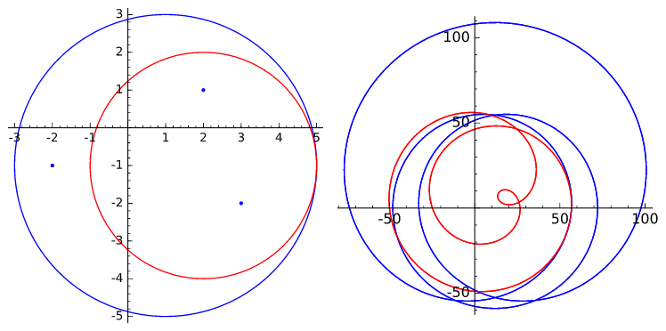

Next we will create some grids and forward map them with $f(z) = z^3$:

```
f(z) = z^3

grid = rect_grid(0,2+2*I,10,10)

zplane = plot_grid(grid)
wplane = plot_grid(grid, f = f)

graphics_array([zplane, wplane])
```

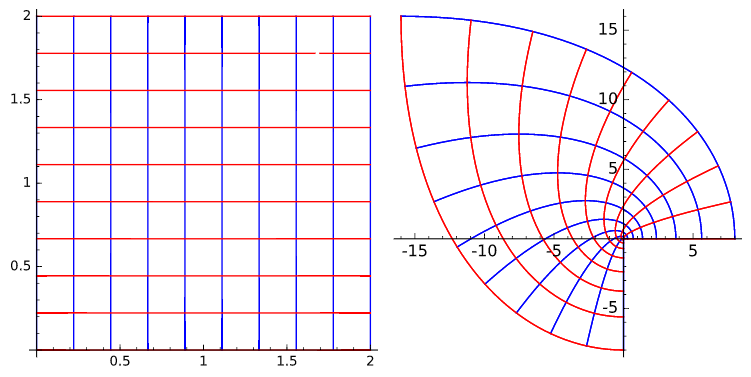

And a polar grid:

```
grid = polar_grid(2, 10, 5, theta0 = pi/6, theta1 = pi/3)

zplane = plot_grid(grid)
wplane = plot_grid(grid, f = f)

graphics_array([zplane, wplane])
```

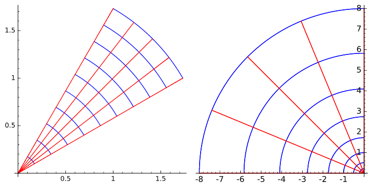

Finally, we will look at a more complicated example: a forward map of the polar grid inside of the unit circle by the function
$$g(z) = \frac{1}{2}\left(z + \frac{1}{z}\right)$$

To show how different parts of the disc map to different parts of the plane, we will split the grid into quadrants, and plot each of them with different colors.

Additional complication is that as $z \to 0$, $g(z) \to \infty$, and the $w$-plane will be kind of messy. We solve that by specifying the lower limit for the second part of the grid (radial lines) in the mapped plot as `a2 = .09`, instead of the default 0.

```
g(z) = 1/2*(z + 1/z)

grid1 = polar_grid(1,10,12, theta0 = 0, theta1 = pi/2)
grid2 = polar_grid(1,10,12, theta0 = pi/2, theta1 = pi)
grid3 = polar_grid(1,10,12, theta0 = pi, theta1 = 3*pi/2)
grid4 = polar_grid(1,10,12, theta0 = 3*pi/2, theta1 = 2*pi)

zplane = plot_grid(grid1) +
         plot_grid(grid2, color1="green", color2="yellow") +
         plot_grid(grid3, color1="magenta", color2="orange") +
         plot_grid(grid4, color1="indigo", color2="deeppink")

wplane = plot_grid(grid1, f = g, a2 = .09) +
         plot_grid(grid2, f = g, a2 = .09, color1="green", color2="yellow") +
         plot_grid(grid3, f = g, a2 = .09, color1="magenta", color2="orange") +
         plot_grid(grid4, f = g, a2 = .09, color1="indigo", color2="deeppink")

graphics_array([zplane, wplane])
```

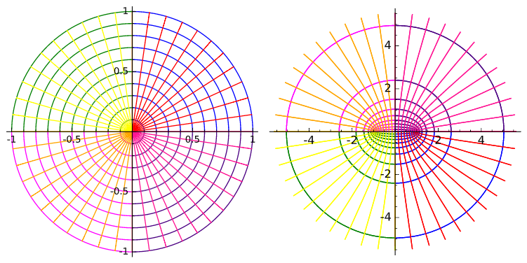